# Statistical Rethinking - chapter 3 solutions

Some setup first:

```r
library(rethinking)

p_grid = seq(0, 1, length.out = 1000)
prior = rep(1, length(p_grid))
lhood = dbinom(6, 9, prob = p_grid)
posterior = lhood * prior
posterior = posterior / sum(posterior)

set.seed(100)
samples = sample(p_grid, prob = posterior, size = 1e4, replace = T)
```

# 3E1

*How much posterior probability lies below p = 0.2?*

```r
sum(samples < 0.2) / length(samples)
```

```
## [1] 4e-04
```

# 3E2

*How much posterior probability lies above p = 0.8?*

```r
sum(samples > 0.8) / length(samples)
```

```
## [1] 0.1116
```

# 3E3

*How much posterior probability lies between p = 0.2 and p = 0.8?*

```r
sum(samples > 0.2 & samples < 0.8) / length(samples)
```

```
## [1] 0.888
```

# 3E4

*20% of the posterior proability lies below which value of p?*

```r
quantile(posterior, 0.2)
```

```
##          20%
## 1.278566e-05
```

# 3E5

*20% of the posterior probabilies lies above which value of p?*

```r
quantile(posterior, 0.8)
```

```
##         80%
## 0.002221751
```

# 3E6

*Which values of p contain the narrowest interval equal to 66% of the posterior probability?*

```r
HPDI(samples, 0.66)
```

```
##     |0.66     0.66|
## 0.5085085 0.7737738
```

# 3E7

*Which values of p contain 66% of the posterior probability, assuming equal posterior probability both below and above the interval?*

```r
PI(samples, 0.66)
```

```
##       17%       83%
## 0.5025025 0.7697698
```

# 3M1

*Suppose the globe tossing data had turned out to be 8 waters in 15 tosses. Construct the posterior distribution, using grid approximation. Use the same flat prior as before*

```r
p_grid = seq(0, 1, length.out = 1000)
prior = rep(1, length(p_grid))
lhood = dbinom(8, 15, prob = p_grid)
posterior = lhood * prior
posterior = posterior / sum(posterior)
```

# 3M2

*Draw 10,000 samples from the grid approximation from above. Then use the samples to calculate the 90% HPDI for p*

```r
set.seed(100)
samples = sample(p_grid, prob = posterior, size = 1e4, replace = T)

HPDI(samples, 0.9)
```

```
##      |0.9      0.9|
## 0.3343343 0.7217217
```

# 3M3

*Construct a posterior predictive check for this model and data. This means simulate the distibution of samples, averaging over the posterior uncertainty in p. What is the proabability of observing 8 waters in 15 tosses?*

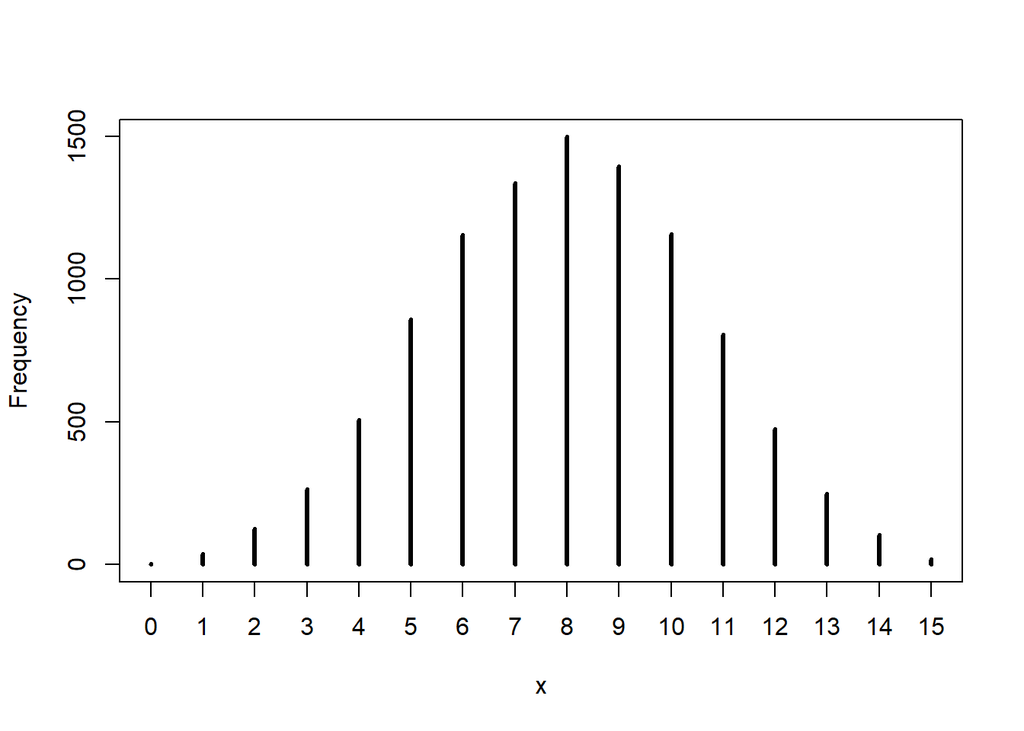

```r
sim_data = rbinom(length(samples), 15, prob = samples)
simplehist(sim_data)
```

```r
sum(sim_data == 8) / length(sim_data)
```

```
## [1] 0.1499
```

# 3M4

*Using the posterior distribution constructed from the new (8/15) data, now calculate the probability of observing 6 waters in 9 tosses*

```r
sim_data = rbinom(length(samples), 9, prob = samples)
sum(sim_data == 6) / length(sim_data)
```

```
## [1] 0.1842
```

# 3M5

*Start over at 3M1, but now use a prior that is zero below p = 0.5 and a constant above p = 0.5. This corresponds to prior information that the majority of the Earth’s surface is water. Repeat each probabl above and compare the inferences. What difference does the better prior make?*

```r
p_grid = seq(0, 1, length.out = 1000)
prior = ifelse(p_grid < 0.5, 0, 1)
lhood = dbinom(8, 15, prob = p_grid)
posterior = lhood * prior
posterior = posterior / sum(posterior)

set.seed(100)
samples = sample(p_grid, prob = posterior, size = 1e4, replace = T)

(HPDI(samples, 0.9))
```

```
##      |0.9      0.9|
## 0.5005005 0.7097097
```

```r
sim_data = rbinom(length(samples), 15, prob = samples)

(sum(sim_data == 8) / length(sim_data))
```

```
## [1] 0.163
```

```r
sim_data = rbinom(length(samples), 9, prob = samples)
(sum(sim_data == 6) / length(sim_data))
```

```
## [1] 0.2353
```

# 3H1

*Using grid approximation, compute the posterior predictive distribution for the probability of a birth being a boy. Assume a uniform prior. Which parameter value maximises the posterior probability?*

```r
data(homeworkch3)

n_boy = sum(birth1) + sum(birth2)
n_birth = length(birth1) + length(birth2)

p_grid = seq(0, 1, length.out = 1000)
prior = rep(1, length(p_grid))
lhood = dbinom(n_boy, n_birth, prob = p_grid)
posterior = lhood * prior
posterior = posterior / sum(posterior)

p_grid[which.max(posterior)]
```

```
## [1] 0.5545546
```

# 3H2

```r
samples = sample(p_grid, prob = posterior, size = 1e4, replace = T)

HPDI(samples, 0.5)
```

```
##      |0.5      0.5|
## 0.5255255 0.5725726
```

```r
HPDI(samples, 0.89)
```

```
##     |0.89     0.89|
## 0.5005005 0.6106106
```

```r
HPDI(samples, 0.97)
```

```
##     |0.97     0.97|
## 0.4734735 0.6276276
```

# 3H3

*Use `rbinom` to simulate 10,000 replicates of 200 births. You should end up with 10,000 numbers, each one a count of boys out of 200 births. Compare the distribution of the predicted number of boys to the actual count (111) in the data. Does it look like the model fits the data well?*

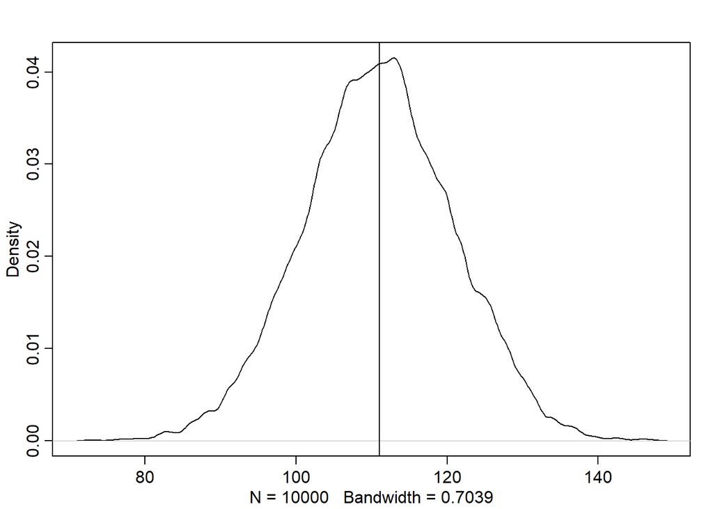

```r
sim_data = rbinom(1e4, 200, prob = samples)
dens(sim_data)
abline(v = n_boy)
```

# 3H4

*Now compare 10,000 counts of boys from 100 simulated first borns only to the number of boys in the first birth data. How does the model look in this light?*

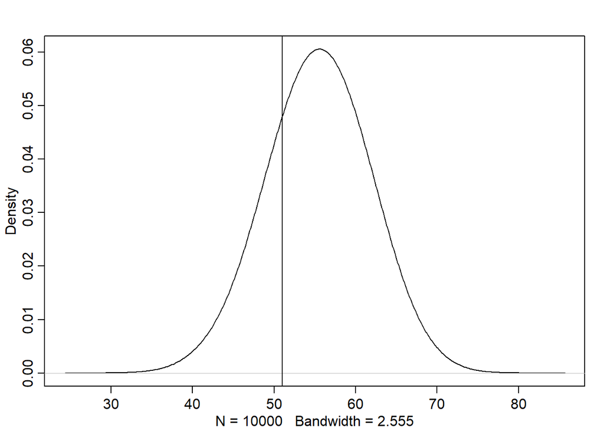

```r
sim_data = rbinom(1e4, 100, prob = samples)
dens(sim_data, adj = 3)
abline(v = sum(birth1))
```

# 3H5

*The model assumes that the sex of the first and second births are independent. To check this assumption, focus now on second births that followed female first borns. COmpare 10,000 simulated counts of boys to only those second births that followed girls. Compare the count of boys in your simulation to the actual observed count of boys following girls. How does the model look in this light? Any guesses what is going on in these data?*

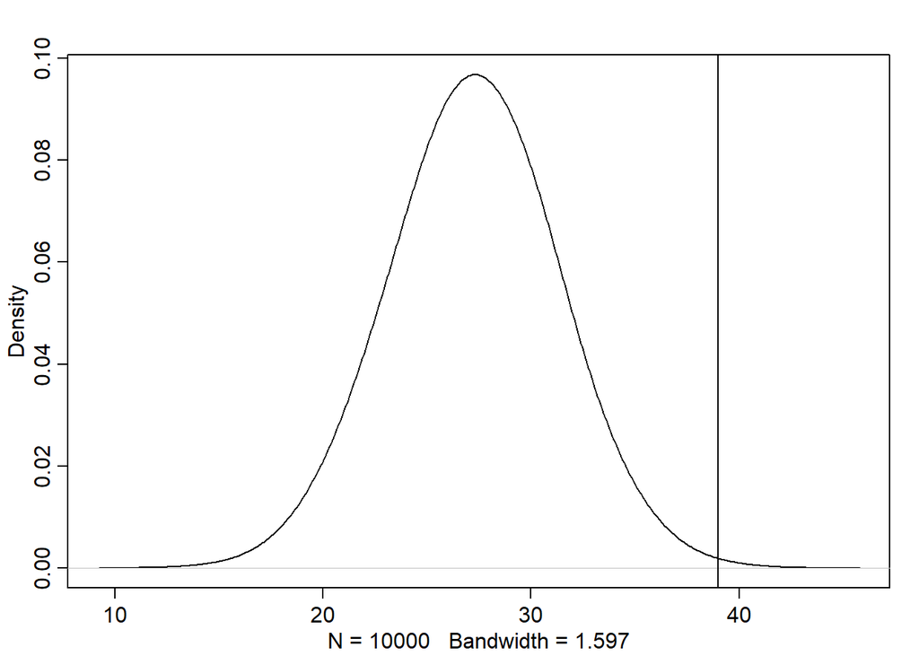

```r
n_girl1 = length(birth1) - sum(birth1)
sim_data = rbinom(1e4, n_girl1, prob = samples)
dens(sim_data, adj = 3)
abline(v = sum(birth2[birth1 == 0]))
```